# Tutorial de R

1- Estructuras de control en R. Realice un ejemplo para las estructuras de control que encuentre en R

2- Vectores en R. Creación, indexación, edición. Genere una secuencia de números utilizando un generador congruencial lineal.

3- Listas y matrices en R. Explique algunas operaciones matriciales básicas

4- Dataframes. Visualización y manipulación. Ejemplo utilización dataframe. Encuentro un dataset en internet o que se encuentre disponible en alguna librería en R y utilice la funcionalidad del dataframe para extraer información del dataset. Utilice las funciones promedio, desviación estándar, varianza para resumir la información en el dataframe.

5- Funciones en R. Ejemplos de utilización. Implemente una función en R de su elección. Explique paso a paso la función y la manera en que retorna los valores finales. Explique también como invocar la función

6- Manejo de archivos con R

7- Ejemplos de visualización de datos: Gráficas diversas incluyendo dispersión de puntos, histogramas, diagrama de cajas (bloxpots), violinplots, etc.

LOs gráficos en R se pueden realizar de forma básica usando las funciones integradas en el lenguaje o avanzada con el paquete ggplot2.

```r
if(!require("AER")) {install.packages("AER")}
#data(package="AER")
#library(AER)
data("CPS1985")
```

Histograma

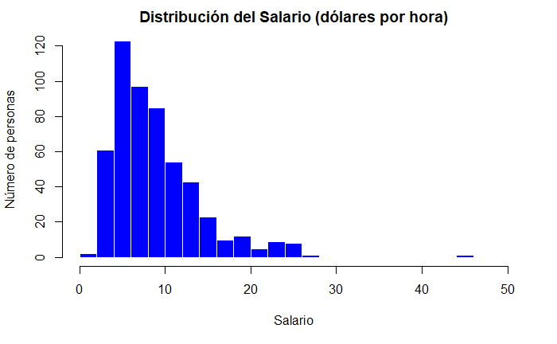

```r
attach(CPS1985)   # acceder directamente a las variables (columnas)
hist(wage,
     breaks = 20,   # número de intervalos
     main = "Distribución del Salario (dólares por hora)",    # título del gráfico
     xlab = "Salario",                                        # título del eje x
     ylab = "Número de personas",                              # título del eje y
     xlim = c(0,50),                      # rango de valores del eje x
     col = "blue",                        # color de relleno
     border = "white"                     # color del borde del rectángulo
     )
```

```r
hist(wage,
     breaks = 20,
     main = "Distribución del Salario (dólares por hora)",
     freq = FALSE,
     xlab = "Salario",
     ylab = "Frecuencia relativa (en tanto por uno)",
     xlim = c(0,50),
     ylim = c(0,0.15),
     col = "blue",
     border = "white"
     )

lines(density(wage), col="yellow", lwd=3)  # dibujamos la distribución normal empírica con los  datos que tenemos
```

```r
lines(density(wage, adjust=2), col="red", lwd=3, lty=2) # adjust=2 lo que hace es suavizar un poco la curva (probad con adjust=1 y adjust=5 para ver las diferencias).
curve(dnorm(x, mean=mean(wage), sd=sd(wage)), add=TRUE, col="orange", lwd=3)  # aquí simulamos valores de una normal con la misma media y deviación típica que wage y la representamos.
```

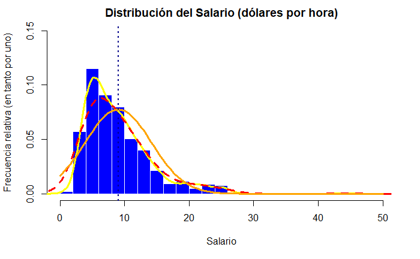

```r
abline(v=mean(wage), lwd=2, lty=3, col="darkblue")    # añadimos posición de la media. Recordemos que e argumento "lwd"" hace referencia al grosor de la línea y "lty"" al tipo de línea.
```

Boxplot

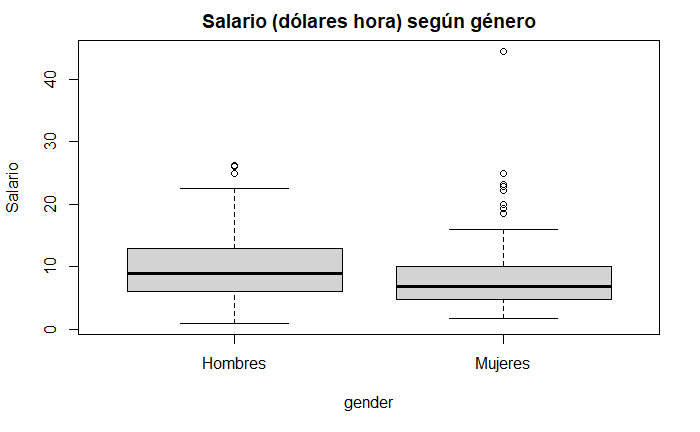

```r
boxplot(wage ~ gender,
        main = "Salario (dólares hora) según género",
        ylab = "Salario",
        names = c("Hombres","Mujeres")   # cambiamos la etiqueta de la variable cualitativa
        )
```

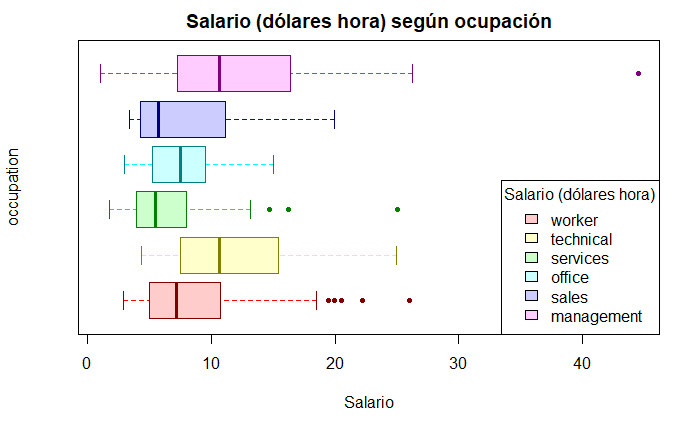

```r
a <- rainbow(6)
b <- rainbow(6, alpha=0.2)
c <- rainbow(6, v=0.5)


boxplot(wage ~ occupation,
        col = b,
        boxcol = c,
        medcol = c,
        whiskcol = a,
        staplecol = c,
        outcol = c,
        outbg = c,
        pch = 20,
        cex = 1,
        horizontal = T,
        main = "Salario (dólares hora) según ocupación",
        xlab = "Salario",
        yaxt = "n"              # elminamos el eje y
        )

legend("bottomright", title="Salario (dólares hora)", levels(occupation), fill=b)
```

Diagrama de dispersiòn

```r
sexo <- as.numeric(gender)

plot (log(wage) ~ experience,
      pch = sexo,
      col = sexo,
      main = "Salario (en logaritmos) en función de la experiencia",
      xlab = "Experiencia (en años)",
      ylab = "Salario (en logaritmos)"
      )

with(CPS1985[gender=="male",], abline(lm(log(wage)~experience), col="red"))
```

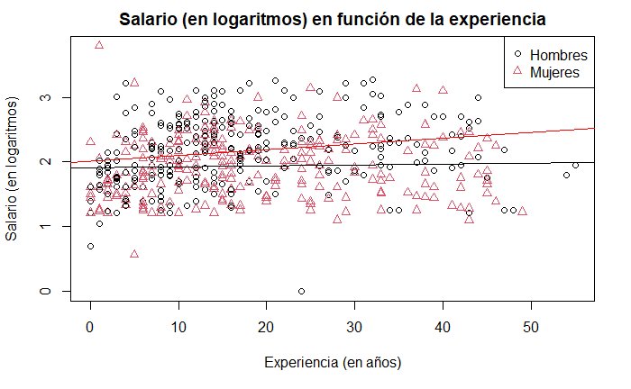

```r
with(CPS1985[gender=="female",], abline(lm(log(wage)~experience), col="black"))

legend("topright", legend=c("Hombres","Mujeres"), pch=1:2, col=1:2, bty="y")
```

Diagrama de barras

```r
educacion <- table(education)
p <- barplot(educacion,
        col = 1:dim(educacion),       # para establecer el número de diferentes colores                                       (=diferentes valores)
        space = 0,                    # no espacio entre las barras
        horiz = F,                    # orientación de las barras
        density = 50 ,                # trama de las barras (se puede modificar el ángulo con                                     el argumento angle)
        ylim = c(0,250)
        )

title("Distribución de la edad", xlab= "Edad (en años)")
```

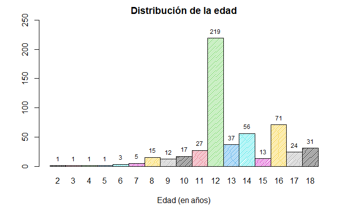

```r
text(p[,1],educacion,labels=educacion, pos=3,cex=0.75)
```

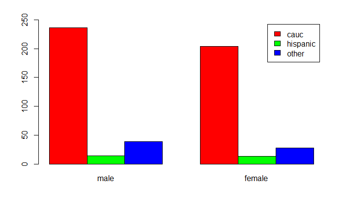

```r
p <- table(ethnicity, gender)
barplot(p,
        beside=T,  # si es FALSE apila
        col=rainbow(3),
        legend=levels(ethnicity),
        names.arg= levels(gender),
        ylim=c(0,250)

)
```

Grafico de sectores

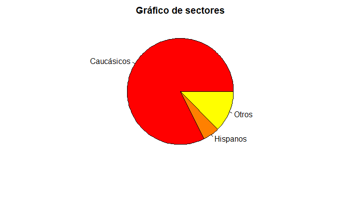

```r
datos <- table(ethnicity)
pie(datos,
    labels=c("Caucásicos", "Hispanos", "Otros"),
    col=heat.colors(3),
    main= "Gráfico de sectores")
```

Gráfico de mosaico

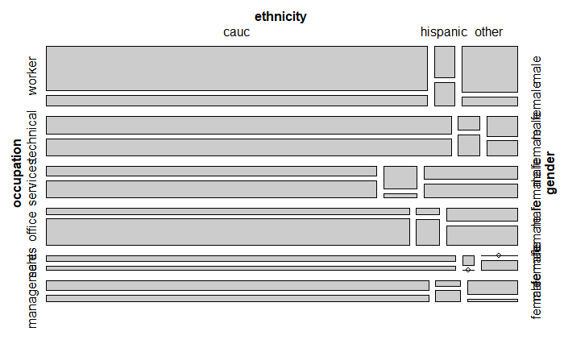

```r
install.packages("vcd")
library(vcd)
datos <- ftable(occupation, ethnicity, gender)
mosaic(~ occupation + ethnicity + gender , dat=datos, las=1)
```

Violinplot

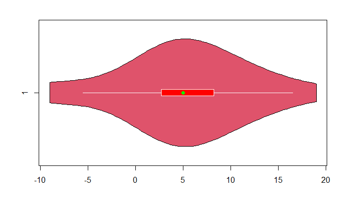

```r
install.packages("vioplot")
library(vioplot)
x <- c(6, 9, 0, 19, -1, 8, 12, 5, 3, 7,
       2, 4, 3, -8, -9, 8, 4, 12, 5, 14)
vioplot(x,
        col = 2,               # Color del área
        rectCol = "red",       # Color del rectángulo
        lineCol = "white",     # Color de la línea
        colMed = "green",      # Color del símbolo pch
        border = "black",      # Color del borde del violín
        pchMed = 16,           # Símbolo pch para la mediana
        plotCentre = "points", # Si "line", dibuja una línea en la mediana
        horizontal = TRUE)
```

```r
data <- chickwts

stripchart(data$weight ~ data$feed, vertical = TRUE, method = "jitter",
           pch = 19, add = TRUE, col = 3:8)
```

[output not shown]

Ahora, veremos los gràficos con ggplot2:

```r
install.packages("ggplot2")
 library(ggplot2)
```

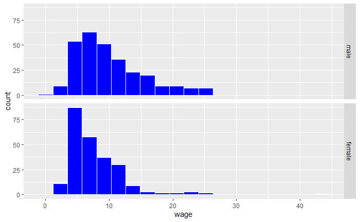

```r
ggplot(CPS1985, aes(x=wage)) +
  geom_histogram(bins=20, color="white", fill="blue") +
  facet_grid(gender~.)
```

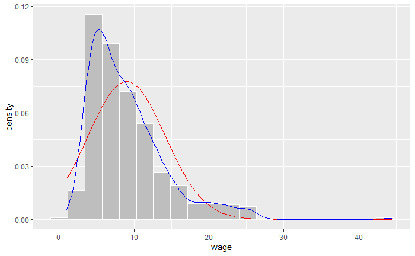

```r
ggplot(CPS1985, aes(x=wage)) +
  geom_histogram(aes(y=..density..), bins=20, color="white", fill="grey") +
  stat_function(fun = dnorm, colour = "red",
                args = list(mean = mean(wage, na.rm = TRUE),
                                 sd = sd(wage, na.rm = TRUE))) +
  geom_line(stat="density", color="blue") +
  expand_limits(y=0)
```